```python
from IPython.display import HTML
HTML('''<script src="https://cdnjs.cloudflare.com/ajax/libs/jquery/2.0.3/jquery.min.js "></script><script>
code_show=true;
function code_toggle() {
if (code_show){
$('div.jp-CodeCell > div.jp-Cell-inputWrapper').hide();
} else {
$('div.jp-CodeCell > div.jp-Cell-inputWrapper').show();
}
code_show = !code_show
}
$( document ).ready(code_toggle);</script><form action="javascript:code_toggle()"><input type="submit" value="Click here to toggle on/off the raw code."></form>
''')
```

[figure not shown]

# Cracking the COVID-19 Code: Unraveling Population Mobility and Behaviors with SafeGraph's Open Census Data

```python
sc.install_pypi_package("matplotlib")
sc.install_pypi_package("pyspark_dist_explore")
sc.install_pypi_package("display")
sc.install_pypi_package("IPython")
sc.install_pypi_package("pandas")
sc.install_pypi_package("boto3")
sc.install_pypi_package("requests")
sc.install_pypi_package("s3fs")
```

```python
import matplotlib.pyplot as plt
import pandas as pd
import s3fs
import requests
from pyspark.sql.functions import (sum, substring,
                                   col, max, desc)

import warnings
warnings.filterwarnings("ignore")
```

# Executive Summary

The COVID-19 pandemic has had a profound impact on societies worldwide. Despite the hight of the pandemic being behind us, understanding the patterns and dynamics of its spread is crucial for effective mitigation and response strategies should a similar pandemic occur again in the future. In this study, we leverage census data and state-level COVID-19 statistics to gain insights into the geographic variations and factors influencing the spread of the virus within the United States. Through our analysis, we found that the implementation of policies to prevent the spread of COVID-19 varied across states, resulting in differing levels of confirmed cases. However, the percentage of the population that died showed less variation, suggesting consistent policies for recovery and treatment. We also observed that the number of cases and deaths did not follow a linear correlation with state population, indicating the presence of unique dynamics for states of different population sizes. Lastly, our study highlighted the impact of multiple waves of COVID-19 on states with the highest and lowest percentages of cases and deaths, providing valuable insights for future pandemic management strategies. To improve our study, we can include mobility and transportation data from the census to gain insights into people's movement, and effectively, the transmission of the pandemic.

# Problem Statement

In this report we want to answer the question,

What insights can we get regarding the spread of the Covid pandemic in the US using census data and the number of cases for each state and are there particular states of interest in the dataset?

# Motivation

The COVID-19 pandemic has posed unprecedented challenges worldwide, impacting all aspects of society. But while the peak of the COVID-19 pandemic seems to have already passed, it is still important to uncover insights and continue to study the events that transpired and how it progressed. Understanding the underlying factors contributing to the spread of COVID-19 within different states can assist health authorities in developing effective mitigation measures and allocating resources where they are most needed in the future. In this study we focus our attention to census data to identify population characteristics and invection rates observed in different states.

# Data Source

Our dataset is taken from Amazon Web Service's marketplace. We accessed it directly with Amazon Web Service's EMR.

**Safegraph Open Census Data**

The SafeGraph Open Census Data on AWS is a comprehensive dataset that provides information on population movement and demographics alongside data on the COVID-19 pandemic. It offers valuable insights into various geographic areas and can be used for various analytical purposes.

Filepath: `covid19-lake/safegraph-open-census-data/`

### Dataset Overview:

Dataset Name: SafeGraph Open Census Data Source: Amazon Web Services  
Contents:

- Anonymized and aggregated data on population movement
- Demographic information related to different geographic locations
- Valuable insights and statistics on population distribution and mobility
- COVID-related data involving cases and deaths

### Original Data Source:

The SafeGraph Open Census Data on AWS is derived from a variety of sources, including mobile applications, GPS data, and other location-based services. The data is processed and made available through the SafeGraph platform, which specializes in location data analysis.

### Accessing the Dataset:

To access the SafeGraph Open Census Data on AWS, you can navigate to the AWS platform and search for the dataset using the appropriate keywords or identifiers. The dataset may be available for download or accessible through specific AWS services, such as Amazon S3. SafeGraph as well has their own site containing the data.

# Data Exploration

As said earlier, there are two parts in this dataset - one on census data and the other on COVID data. The census data is divided into file type-based categories - CSVs and JSONs, which contains all sorts of tables labeled with coded headers. The coded headers correspond to different things. The first six characters refer to the type of table's contents featured and the latter characters referring to area/location. For example if you have a header name/title being "B08303m13", it would be "Travel Time to Work Residence 1 Year Ago in the Combined New England City and Town Area" with B08303 referring to "TRAVEL TIME TO WORK" and m13 referring to "Residence 1 Year Ago - Combined New England City and Town Area". The table below details some of what is in the data dictionaries.

### 2021 Data Product List

| Table ID | Table Title |
| --- | --- |
| B01001 | SEX BY AGE |
| B01001A | SEX BY AGE (WHITE ALONE) |
| C01001A | SEX BY AGE (WHITE ALONE) |
| B01001B | SEX BY AGE (BLACK OR AFRICAN AMERICAN ALONE) |
| C01001B | SEX BY AGE (BLACK OR AFRICAN AMERICAN ALONE) |
| B01001C | SEX BY AGE (AMERICAN INDIAN AND ALASKA NATIVE ALONE) |
| C01001C | SEX BY AGE (AMERICAN INDIAN AND ALASKA NATIVE ALONE) |
| B01001D | SEX BY AGE (ASIAN ALONE) |
| C01001D | SEX BY AGE (ASIAN ALONE) |
| B01001E | SEX BY AGE (NATIVE HAWAIIAN AND OTHER PACIFIC ISLANDER ALONE) |
| C01001E | SEX BY AGE (NATIVE HAWAIIAN AND OTHER PACIFIC ISLANDER ALONE) |
| B01001F | SEX BY AGE (SOME OTHER RACE ALONE) |
| C01001F | SEX BY AGE (SOME OTHER RACE ALONE) |
| B01001G | SEX BY AGE (TWO OR MORE RACES) |

### 1-year Published Summary Levels

| Summary Level Code | Geographic Component Code | Summary Level Description |
| --- | --- | --- |
| 010 | 00 | United States |
| 010 | 01 | United States; Urban |
| 010 | 43 | United States; Rural |
| 010 | A0 | United States; In Metropolitan or Micropolitan Statistical Area |
| 010 | G0 | United States; Not In Metropolitan or Micropolitan Statistical Area |
| 010 | C0 | United States; In Metropolitan Statistical Area |
| 010 | C1 | United States; In Metropolitan Statistical Area-In Principal City |
| 010 | C2 | United States; In Metropolitan Statistical Area-Not In Principal City |
| 010 | H0 | United States; Not In Metropolitan Statistical Area |
| 010 | E0 | United States; In Micropolitan Statistical Area |
| 010 | E1 | United States; In Micropolitan Statistical Area-In Principal City |
| 010 | E2 | United States; In Micropolitan Statistical Area-Not In Principal City |
| 010 | 89 | United States; American Indian Reservation and Trust Land-Federal |
| 010 | 91 | United States; Oklahoma Tribal Statistical Area |

### Data Pre-Processing

```python
census_path = 'covid19-lake/safegraph-open-census-data/csv/data/cbg_b01.csv'
tot_pop_df = spark.read.csv('s3://'+census_path, header=True)
```

```
VBox()
```

```
FloatProgress(value=0.0, bar_style='info', description='Progress:', layout=Layout(height='25px', width='50%'),…
```

```python
tot_pop_df.toPandas()
```

```
VBox()
```

```
FloatProgress(value=0.0, bar_style='info', description='Progress:', layout=Layout(height='25px', width='50%'),…
```

```
       census_block_group B01001e1 B01001m1  ... B01002Im3 B01003e1 B01003m1
0            010010201001      745      226  ...      None      745      226
1            010010201002     1265      232  ...      None     1265      232
2            010010202001      960      261  ...      None      960      261
3            010010202002     1236      227  ...      None     1236      227
4            010010203001     2364      378  ...      15.6     2364      378
...                   ...      ...      ...  ...       ...      ...      ...
220328       721537506011      921      332  ...      29.6      921      332
220329       721537506012     2703      531  ...       7.6     2703      531
220330       721537506013     1195      425  ...      22.8     1195      425
220331       721537506021     2005      471  ...       7.7     2005      471
220332       721537506022      736      371  ...       9.2      736      371

[220333 rows x 161 columns]
```

```python
covid_path = 'covid19-lake/rearc-covid-19-nyt-data-in-usa/csv/us-states/us-states.csv'
covid_df = spark.read.csv('s3://'+covid_path, header=True)
```

```
VBox()
```

```
FloatProgress(value=0.0, bar_style='info', description='Progress:', layout=Layout(height='25px', width='50%'),…
```

```python
# Group by state
_df = (tot_pop_df.withColumn("fips",
                             substring(col("census_block_group"), 1, 2))
       .select('B01003e1', 'fips'))
_df = _df.groupBy('fips').agg(sum('B01003e1')).orderBy('fips')
_pdf = _df.toPandas()
_pdf
```

```
VBox()
```

```
FloatProgress(value=0.0, bar_style='info', description='Progress:', layout=Layout(height='25px', width='50%'),…
```

```
   fips  sum(B01003e1)
0    01      4841164.0
1    02       736855.0
2    04      6728577.0
3    05      2968472.0
4    06     38654206.0
5    08      5359295.0
6    09      3588570.0
7    10       934695.0
8    11       659009.0
9    12     19934451.0
10   13     10099320.0
11   15      1413673.0
12   16      1635483.0
13   17     12851684.0
```

[output cut: 38 more lines]

```python
cv_pdf = covid_df.toPandas()
cv_pdf
```

```
VBox()
```

```
FloatProgress(value=0.0, bar_style='info', description='Progress:', layout=Layout(height='25px', width='50%'),…
```

```
             date          state fips    cases deaths
0      2020-01-21     Washington   53        1      0
1      2020-01-22     Washington   53        1      0
2      2020-01-23     Washington   53        1      0
3      2020-01-24       Illinois   17        1      0
4      2020-01-24     Washington   53        1      0
...           ...            ...  ...      ...    ...
46145  2022-06-14       Virginia   51  1827418  20443
46146  2022-06-14     Washington   53  1620601  13103
46147  2022-06-14  West Virginia   54   523876   7013
46148  2022-06-14      Wisconsin   55  1701333  14699
46149  2022-06-14        Wyoming   56   162160   1824

[46150 rows x 5 columns]
```

```python
# join census data with covid data
merged = (covid_df.join(_df, on='fips', how='inner')
          .orderBy('date')
          .withColumn('case_pct',
                       col('cases') / col('sum(B01003e1)') * 100)
          .withColumn('death_pct',
                       col('deaths') / col('sum(B01003e1)') * 100))
merged_pdf = merged.toPandas()
merged_pdf
```

```
VBox()
```

```
FloatProgress(value=0.0, bar_style='info', description='Progress:', layout=Layout(height='25px', width='50%'),…
```

```
      fips        date       state  ... sum(B01003e1)   case_pct  death_pct
0       53  2020-01-21  Washington  ...     7073146.0   0.000014   0.000000
1       53  2020-01-22  Washington  ...     7073146.0   0.000014   0.000000
2       53  2020-01-23  Washington  ...     7073146.0   0.000014   0.000000
3       53  2020-01-24  Washington  ...     7073146.0   0.000014   0.000000
4       17  2020-01-24    Illinois  ...    12851684.0   0.000008   0.000000
...    ...         ...         ...  ...           ...        ...        ...
43425   23  2022-06-14       Maine  ...     1329923.0  20.044394   0.180838
43426   22  2022-06-14   Louisiana  ...     4645670.0  27.540871   0.373724
43427   21  2022-06-14    Kentucky  ...     4411989.0  31.525260   0.364076
43428   49  2022-06-14        Utah  ...     2948427.0  32.642524   0.162561
43429   50  2022-06-14     Vermont  ...      626249.0  21.344385   0.107465

[43430 rows x 8 columns]
```

# Methodology

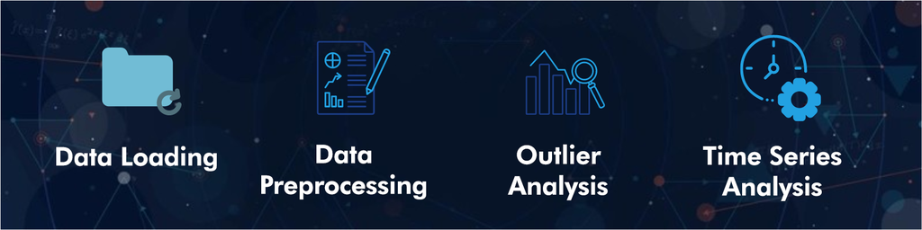

Firstly, the census data containing population information and the COVID-19 data with case and death counts are loaded. Next, the datasets are merged based on the FIPS code, to get the total population and COVID-19 information for each state. We then calculated the percentage of cases per state with respect to the total population which can be calculated from the total number of cases aggregated per state, which is divided by the corresponding population. We looked at boxplots to identify outliers in terms of percentage of cases and deaths. To explore the time series aspect, states with the highest and lowest case percentages are identified and compared to see how these states responded to the waves of COVID-19.

# Descriptive Analytics

In this section, we will look at the condition of the differnt states from different angles.

### Distribution

First, we look at the percentage of the population that were confirmed cases during the final day of recording.

```python
# compare case percentages of each state at the final date
final_case = (merged.groupBy('fips')
              .agg(max('case_pct'))
              .orderBy(desc("max(case_pct)")))
pd_final_case = final_case.toPandas()
pd_final_case
```

```
VBox()
```

```
FloatProgress(value=0.0, bar_style='info', description='Progress:', layout=Layout(height='25px', width='50%'),…
```

```
   fips  max(case_pct)
0    44      37.766278
1    02      35.826044
2    38      33.490455
3    49      32.642524
4    12      31.641373
5    45      31.538688
6    21      31.525260
7    47      31.110403
8    04      30.873482
9    10      29.983257
10   55      29.563731
11   05      28.677212
12   54      28.377567
13   46      28.355999
```

[output cut: 38 more lines]

```
VBox()
```

```
FloatProgress(value=0.0, bar_style='info', description='Progress:', layout=Layout(height='25px', width='50%'),…
```

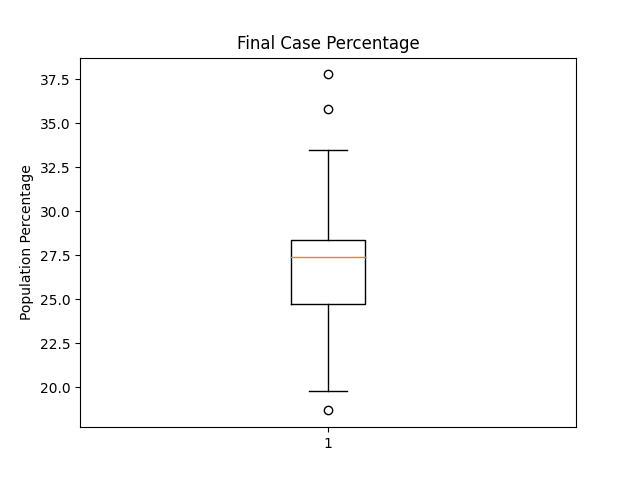

```python
plt.figure('cases')
plt.boxplot(pd_final_case["max(case_pct)"])
plt.title("Final Case Percentage")
plt.xlabel(None)
plt.ylabel("Population Percentage")
# plt.show()
%matplot plt
```

It appears that there are outliers for the number of cases which implies that people are more/less exposed than others in certain states. Rhode Islands being the state with the highest percentage of the population that are confirmed cases and Maryland being the state with the lowest percentage of the population as confirmed cases.

```python
# compare death percentages of each state at the final date
final_death = (merged.groupBy('fips')
              .agg(max('death_pct'))
              .orderBy(desc("max(death_pct)")))
pd_final_death = final_death.toPandas()
pd_final_death
```

```
VBox()
```

```
FloatProgress(value=0.0, bar_style='info', description='Progress:', layout=Layout(height='25px', width='50%'),…
```

```
   fips  max(death_pct)
0    04        0.451388
1    28        0.417805
2    01        0.406824
3    47        0.401252
4    05        0.388314
5    32        0.385641
6    34        0.380014
7    54        0.379884
8    35        0.378121
9    12        0.375997
10   22        0.373724
11   40        0.373053
12   45        0.372212
13   26        0.368713
```

[output cut: 38 more lines]

```
VBox()
```

```
FloatProgress(value=0.0, bar_style='info', description='Progress:', layout=Layout(height='25px', width='50%'),…
```

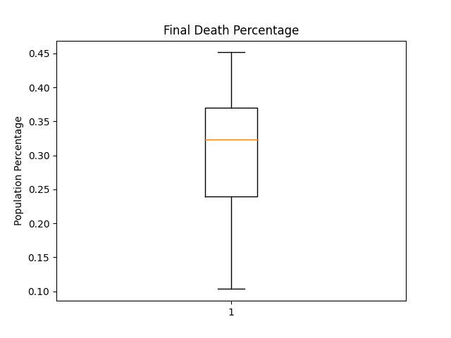

```python
plt.figure('deaths')
plt.boxplot(pd_final_death["max(death_pct)"])
plt.title("Final Death Percentage")
plt.xlabel(None)
plt.ylabel("Population Percentage")
# plt.show()
%matplot plt
```

On the other hand, there seems to be no outliers for the number of deaths for all states which implies that policies regarding COVID-19 treatment might have been more strictly implemented than prevention policies. We identified Arizona as the state with the highest death percentage while Hawaii has the lowest.

### Population Analysis

An intuitive question we would ask is whether a higher population total corresponds to a higher number of cases. We investgate this question in this section.

```python
case_vs_pop = final_case.join(_df, on='fips', how='inner').toPandas()
case_vs_pop
```

```
VBox()
```

```
FloatProgress(value=0.0, bar_style='info', description='Progress:', layout=Layout(height='25px', width='50%'),…
```

```
   fips  max(case_pct)  sum(B01003e1)
0    01      27.469158      4841164.0
1    18      26.571853      6589578.0
2    27      28.121099      5450868.0
3    26      25.892256      9909600.0
4    25      28.186528      6742143.0
5    06      25.482580     38654206.0
6    15      20.059377      1413673.0
7    29      24.622095      6059651.0
8    23      20.044394      1329923.0
9    13      24.923807     10099320.0
10   22      27.540871      4645670.0
11   28      27.346855      2989192.0
12   24      18.674334      5959902.0
13   16      27.896713      1635483.0
```

[output cut: 38 more lines]

```
VBox()
```

```
FloatProgress(value=0.0, bar_style='info', description='Progress:', layout=Layout(height='25px', width='50%'),…
```

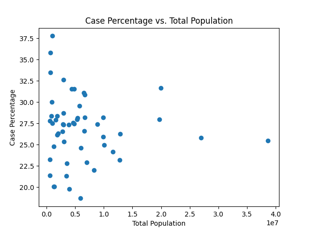

```python
plt.figure('cvp')
plt.scatter(case_vs_pop['sum(B01003e1)'],
            case_vs_pop['max(case_pct)'])
plt.title("Case Percentage vs. Total Population")
plt.xlabel('Total Population')
plt.ylabel("Case Percentage")
# plt.show()
%matplot plt
```

```python
death_vs_pop = final_death.join(_df, on='fips', how='inner').toPandas()
death_vs_pop
```

```
VBox()
```

```
FloatProgress(value=0.0, bar_style='info', description='Progress:', layout=Layout(height='25px', width='50%'),…
```

```
   fips  max(death_pct)  sum(B01003e1)
0    01        0.406824      4841164.0
1    18        0.361146      6589578.0
2    27        0.239210      5450868.0
3    26        0.368713      9909600.0
4    25        0.352277      6742143.0
5    06        0.237894     38654206.0
6    15        0.103419      1413673.0
7    29        0.343436      6059651.0
8    23        0.180838      1329923.0
9    13        0.364411     10099320.0
10   22        0.373724      4645670.0
11   28        0.417805      2989192.0
12   24        0.246548      5959902.0
13   16        0.302846      1635483.0
```

[output cut: 38 more lines]

```
VBox()
```

```
FloatProgress(value=0.0, bar_style='info', description='Progress:', layout=Layout(height='25px', width='50%'),…
```

[figure not shown]

```python
plt.figure('dvp')
plt.scatter(death_vs_pop['sum(B01003e1)'],
            death_vs_pop['max(death_pct)'])
plt.title("Death Percentage vs. Total Population")
plt.xlabel('Total Population')
plt.ylabel("Death Percentage")
# plt.show()
%matplot plt
```

As we can see, there is no clear linear correlation between the case/death percentage and the total population. We see that the state of California with the highest population is not the state with the highest number of cases/deaths.

### Case/Death Percentage Progression

In this section, we investigate the states with the highest percentage if cases and deaths to see if we can identify how differently they performed.

```python
rhode = merged.where(col('fips') == 44).orderBy('date').toPandas()
maryland = merged.where(col('fips') == 24).orderBy('date').toPandas()
maryland
```

```
VBox()
```

```
FloatProgress(value=0.0, bar_style='info', description='Progress:', layout=Layout(height='25px', width='50%'),…
```

```
    fips        date     state  ... sum(B01003e1)   case_pct  death_pct
0     24  2020-03-05  Maryland  ...     5959902.0   0.000050   0.000000
1     24  2020-03-06  Maryland  ...     5959902.0   0.000050   0.000000
2     24  2020-03-07  Maryland  ...     5959902.0   0.000050   0.000000
3     24  2020-03-08  Maryland  ...     5959902.0   0.000084   0.000000
4     24  2020-03-09  Maryland  ...     5959902.0   0.000101   0.000000
..   ...         ...       ...  ...           ...        ...        ...
827   24  2022-06-10  Maryland  ...     5959902.0  18.585171   0.246162
828   24  2022-06-11  Maryland  ...     5959902.0  18.585171   0.246162
829   24  2022-06-12  Maryland  ...     5959902.0  18.585171   0.246162
830   24  2022-06-13  Maryland  ...     5959902.0  18.616850   0.246279
831   24  2022-06-14  Maryland  ...     5959902.0  18.674334   0.246548

[832 rows x 8 columns]
```

```
VBox()
```

```
FloatProgress(value=0.0, bar_style='info', description='Progress:', layout=Layout(height='25px', width='50%'),…
```

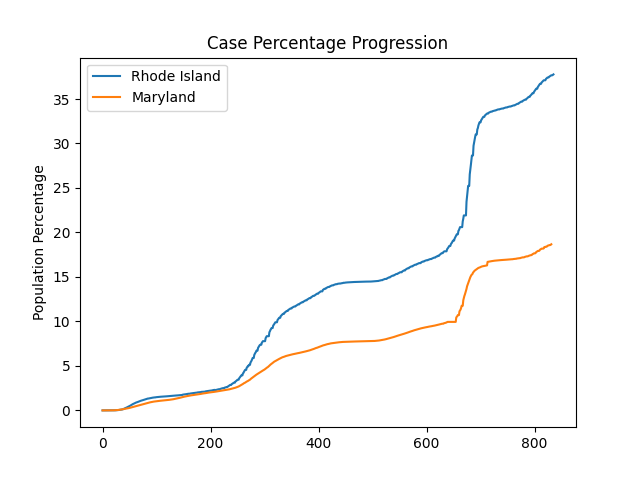

```python
plt.figure('cases_ts')
plt.plot(rhode["case_pct"], label='Rhode Island')
plt.plot(maryland["case_pct"], label='Maryland')
plt.title("Case Percentage Progression")
plt.xlabel(None)
plt.ylabel("Population Percentage")
plt.legend()
# plt.show()
%matplot plt
```

The trend for COVID-19 cases show two major waves affecting both states. Interestingly, both states performed similarly before the first wave. Although after the second wave (first wave being the initial outbreak), Rhode Island wasn't able to control the situation as well as Maryland which probably cascaded and propagated until the last day of recording.

```python
arizona = merged.where(col('fips') == 4).orderBy('date').toPandas()
hawaii = merged.where(col('fips') == 15).orderBy('date').toPandas()
hawaii
```

```
VBox()
```

```
FloatProgress(value=0.0, bar_style='info', description='Progress:', layout=Layout(height='25px', width='50%'),…
```

```
    fips        date   state  ... sum(B01003e1)   case_pct  death_pct
0     15  2020-03-06  Hawaii  ...     1413673.0   0.000071   0.000000
1     15  2020-03-07  Hawaii  ...     1413673.0   0.000071   0.000000
2     15  2020-03-08  Hawaii  ...     1413673.0   0.000141   0.000000
3     15  2020-03-09  Hawaii  ...     1413673.0   0.000141   0.000000
4     15  2020-03-10  Hawaii  ...     1413673.0   0.000141   0.000000
..   ...         ...     ...  ...           ...        ...        ...
826   15  2022-06-10  Hawaii  ...     1413673.0  20.059377   0.103419
827   15  2022-06-11  Hawaii  ...     1413673.0  20.059377   0.103419
828   15  2022-06-12  Hawaii  ...     1413673.0  20.059377   0.103419
829   15  2022-06-13  Hawaii  ...     1413673.0  20.059377   0.103419
830   15  2022-06-14  Hawaii  ...     1413673.0  20.059377   0.103419

[831 rows x 8 columns]
```

```
VBox()
```

```
FloatProgress(value=0.0, bar_style='info', description='Progress:', layout=Layout(height='25px', width='50%'),…
```

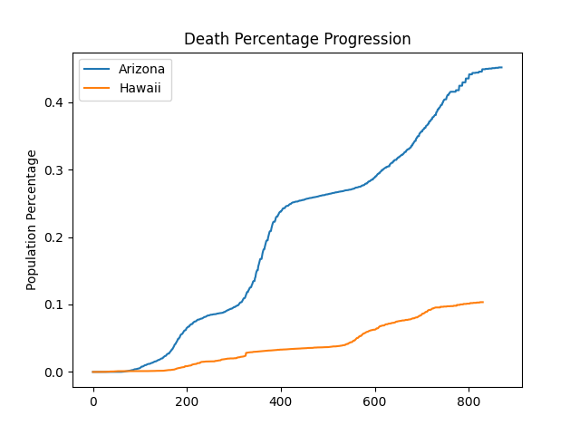

```python
plt.figure('death_ts')
plt.plot(arizona["death_pct"], label='Arizona')
plt.plot(hawaii["death_pct"], label='Hawaii')
plt.title("Death Percentage Progression")
plt.xlabel(None)
plt.ylabel("Population Percentage")
plt.legend()
# plt.show()
%matplot plt
```

For the death percentage on the other hand, the general trend shows an initial wave of deaths before the second wave of cases which had a much greater and observable effect on Arizona than Hawaii. The same could be said of the 2nd and 3rd wave of deaths where rapid increase in the percentage can be seen in Arizona, but not in Hawaii.

# Results and Discussions

We found several insights during the exploration of the dataset. Firstly, we found that the different states likely had varying degrees of implementation with regards to policies preventing the spread of the pandemic which is why we see outliers in the percentage of the population that are confirmed cases. But despite this, we see no outliers in terms of the percentage of the population that died. This suggests that policies regarding COVID-19 recovery and treatment were likely more strictly implemented for all states. We also found that the number of cases and deaths are not linearly correlated with the total population of the state. This implies that there are different dynamics at play with regards to preventing cases and deaths as the population increases. Lastly, we looked at the progression of the percentage of cases and deaths for the states with the highest and lowest percentage and saw how those states were differently affected by the multiple waves of covid cases.